# Final Project - 414 - Wine data

# **Data Description**

#### The distribution of wine types is slightly imbalanced, with 59 samples of Type 1, 71 samples of Type 2, and 48 samples of Type 3, as shown by the frequency table.

#### A missing-value check confirms that there are no missing entries in any variable (colSums(is.na(wine)) = 0 for all columns). This ensures that the dataset can be used directly for PCA and clustering without the need for imputation or data cleaning.

## **EDA - Exploratory Data Analysis**

### Histograms for all chemical variables

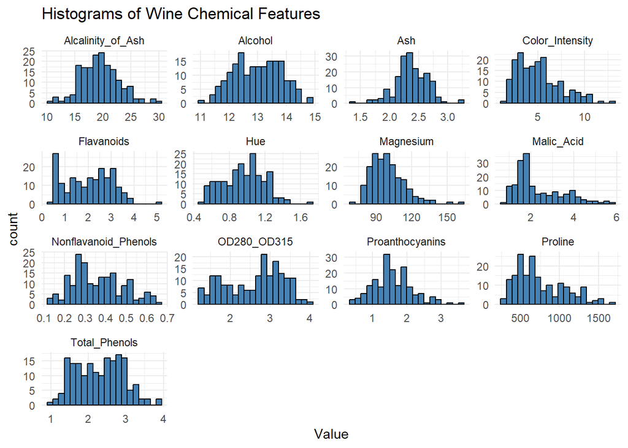

```r
wine %>%
  select(-Type) %>%
  pivot_longer(cols = everything(),
               names_to = "Variable",
               values_to = "Value") %>%
  ggplot(aes(x = Value)) +
  geom_histogram(bins = 20, fill = "steelblue", color = "black") +
  facet_wrap(~ Variable, scales = "free") +
  theme_minimal() +
  labs(title = "Histograms of Wine Chemical Features")
```

### Boxplots to identify skewness/outliers more clearly

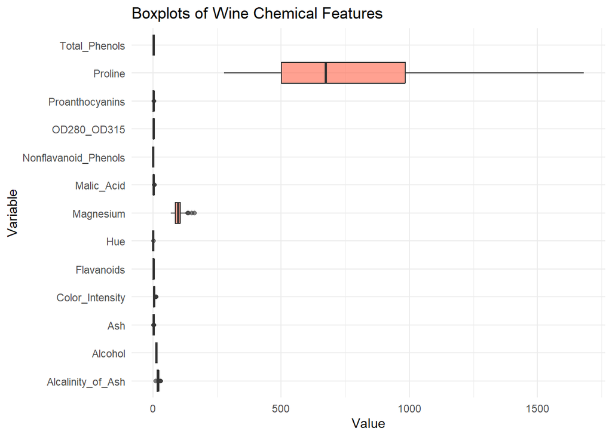

```r
wine %>%
  select(-Type) %>%
  pivot_longer(cols = everything(),
               names_to = "Variable",
               values_to = "Value") %>%
  ggplot(aes(y = Value, x = Variable)) +
  geom_boxplot(fill = "tomato", alpha = 0.6) +
  coord_flip() +
  theme_minimal() +
  labs(title = "Boxplots of Wine Chemical Features")
```

### Correlation martrix

```r
library(knitr)
corr_matrix <- round(cor(wine[, -1]), 3)

knitr::kable(corr_matrix,
             caption = "Correlation Matrix of Wine Chemical Features")
```

Correlation Matrix of Wine Chemical Features

|  | Alcohol | Malic_Acid | Ash | Alcalinity_of_Ash | Magnesium | Total_Phenols | Flavanoids | Nonflavanoid_Phenols | Proanthocyanins | Color_Intensity | Hue | OD280_OD315 | Proline |
| --- | --- | --- | --- | --- | --- | --- | --- | --- | --- | --- | --- | --- | --- |
| Alcohol | 1.000 | 0.094 | 0.212 | -0.310 | 0.271 | 0.289 | 0.237 | -0.156 | 0.137 | 0.546 | -0.072 | 0.072 | 0.644 |
| Malic_Acid | 0.094 | 1.000 | 0.164 | 0.289 | -0.055 | -0.335 | -0.411 | 0.293 | -0.221 | 0.249 | -0.561 | -0.369 | -0.192 |
| Ash | 0.212 | 0.164 | 1.000 | 0.443 | 0.287 | 0.129 | 0.115 | 0.186 | 0.010 | 0.259 | -0.075 | 0.004 | 0.224 |
| Alcalinity_of_Ash | -0.310 | 0.289 | 0.443 | 1.000 | -0.083 | -0.321 | -0.351 | 0.362 | -0.197 | 0.019 | -0.274 | -0.277 | -0.441 |
| Magnesium | 0.271 | -0.055 | 0.287 | -0.083 | 1.000 | 0.214 | 0.196 | -0.256 | 0.236 | 0.200 | 0.055 | 0.066 | 0.393 |
| Total_Phenols | 0.289 | -0.335 | 0.129 | -0.321 | 0.214 | 1.000 | 0.865 | -0.450 | 0.612 | -0.055 | 0.434 | 0.700 | 0.498 |
| Flavanoids | 0.237 | -0.411 | 0.115 | -0.351 | 0.196 | 0.865 | 1.000 | -0.538 | 0.653 | -0.172 | 0.543 | 0.787 | 0.494 |
| Nonflavanoid_Phenols | -0.156 | 0.293 | 0.186 | 0.362 | -0.256 | -0.450 | -0.538 | 1.000 | -0.366 | 0.139 | -0.263 | -0.503 | -0.311 |
| Proanthocyanins | 0.137 | -0.221 | 0.010 | -0.197 | 0.236 | 0.612 | 0.653 | -0.366 | 1.000 | -0.025 | 0.296 | 0.519 | 0.330 |
| Color_Intensity | 0.546 | 0.249 | 0.259 | 0.019 | 0.200 | -0.055 | -0.172 | 0.139 | -0.025 | 1.000 | -0.522 | -0.429 | 0.316 |
| Hue | -0.072 | -0.561 | -0.075 | -0.274 | 0.055 | 0.434 | 0.543 | -0.263 | 0.296 | -0.522 | 1.000 | 0.565 | 0.236 |
| OD280_OD315 | 0.072 | -0.369 | 0.004 | -0.277 | 0.066 | 0.700 | 0.787 | -0.503 | 0.519 | -0.429 | 0.565 | 1.000 | 0.313 |
| Proline | 0.644 | -0.192 | 0.224 | -0.441 | 0.393 | 0.498 | 0.494 | -0.311 | 0.330 | 0.316 | 0.236 | 0.313 | 1.000 |

#### To better understand the characteristics of the wine dataset, several exploratory analyses were conducted, including visualization of distributions, identification of outliers, and examination of correlations among variables.

### **Distribution of Chemical Features**

#### - Boxplots further highlight the presence of significant outliers in several variables. In particular:

#### - Magnesium contains a few high-value outliers.

#### - Proline displays a very large spread, ranging from approximately 300 to 1700.

#### - Color_Intensity shows a wide range with upper long-tailed values.

#### These observations indicate that the dataset contains variables measured on different scales and with varying degrees of skewness, making data standardization essential before applying PCA or clustering.

### **Correlation Analysis**

#### A correlation matrix was computed for all chemical variables (excluding the Type label). Several strong relationships were observed:

### **Strong positive correlations:**

#### - Total_Phenols and Flavanoids (0.865)

#### - Flavanoids and OD280_OD315 (0.787)

#### - Total_Phenols and OD280_OD315 (0.700)

#### - Proanthocyanins and Flavanoids (0.653)

#### - Alcohol and Proline (0.644)

#### - Color_Intensity and Alcohol (0.546)

#### These strong associations indicate that many polyphenol-related features (Flavanoids, OD280_OD315, Total_Phenols, Proanthocyanins) tend to increase together, reflecting underlying chemical composition patterns.

### **Strong negative correlations:**

#### - Hue and Color_Intensity (-0.522)

#### - Nonflavanoid_Phenols and OD280_OD315 (-0.503)

#### - Malic_Acid and Hue (-0.561)

#### These negative relationships suggest contrasting chemical characteristics across wine types—for example, wines with deeper color intensity tend to have lower hue values.

### **Implications for Modeling:**

### **The presence of:**

#### - Strong correlations

#### - High variance across features

#### - Outliers

#### - Different measurement scales

#### Motivates the use of Principal Component Analysis (PCA) to reduce dimensionality and reveal dominant patterns in the data. Similarly, K-means and hierarchical clustering should be applied on standardized data to avoid giving undue influence to variables with large ranges such as Proline and Color_Intensity.

# **Methodology**

```r
# Extract feature matrix
X <- as.matrix(wine[, -1])   # numerical variables only
y <- wine$Type               # true labels

# Compute column means and standard deviations (before scaling)
colMeans(X)
```

```
##              Alcohol           Malic_Acid                  Ash
##           13.0006180            2.3363483            2.3665169
##    Alcalinity_of_Ash            Magnesium        Total_Phenols
##           19.4949438           99.7415730            2.2951124
##           Flavanoids Nonflavanoid_Phenols      Proanthocyanins
##            2.0292697            0.3618539            1.5908989
##      Color_Intensity                  Hue          OD280_OD315
##            5.0580899            0.9574494            2.6116854
##              Proline
##          746.8932584
```

```r
apply(X, 2, sd)
```

```
##              Alcohol           Malic_Acid                  Ash
##            0.8118265            1.1171461            0.2743440
##    Alcalinity_of_Ash            Magnesium        Total_Phenols
##            3.3395638           14.2824835            0.6258510
##           Flavanoids Nonflavanoid_Phenols      Proanthocyanins
##            0.9988587            0.1244533            0.5723589
##      Color_Intensity                  Hue          OD280_OD315
##            2.3182859            0.2285716            0.7099904
##              Proline
##          314.9074743
```

```r
# Standardize variables: mean = 0, sd = 1
X.scaled <- scale(X)

# Verify scaling
round(apply(X.scaled, 2, mean), 4)
```

```
##              Alcohol           Malic_Acid                  Ash
##                    0                    0                    0
##    Alcalinity_of_Ash            Magnesium        Total_Phenols
##                    0                    0                    0
##           Flavanoids Nonflavanoid_Phenols      Proanthocyanins
##                    0                    0                    0
##      Color_Intensity                  Hue          OD280_OD315
##                    0                    0                    0
##              Proline
##                    0
```

```r
round(apply(X.scaled, 2, sd), 4)
```

```
##              Alcohol           Malic_Acid                  Ash
##                    1                    1                    1
##    Alcalinity_of_Ash            Magnesium        Total_Phenols
##                    1                    1                    1
##           Flavanoids Nonflavanoid_Phenols      Proanthocyanins
##                    1                    1                    1
##      Color_Intensity                  Hue          OD280_OD315
##                    1                    1                    1
##              Proline
##                    1
```

#### Before applying PCA and clustering, the chemical variables were examined and found to be on very different numerical scales. For example, Proline values are in the hundreds, while several phenolic measurements are below 1. Because PCA and distance-based clustering are both sensitive to variable scale, features with larger ranges would dominate the analysis and distort the results. To prevent this, all variables were standardized using scale() so that each has mean 0 and standard deviation 1. The verification step confirms that the scaled data meet these conditions, ensuring that all chemical features contribute equally to PCA and clustering.

```r
# Run PCA on standardized data
pca <- prcomp(X.scaled, center = FALSE, scale. = FALSE)

# Summary of PCA
summary(pca)
```

```
## Importance of components:
##                          PC1    PC2    PC3     PC4     PC5     PC6     PC7
## Standard deviation     2.169 1.5802 1.2025 0.95863 0.92370 0.80103 0.74231
## Proportion of Variance 0.362 0.1921 0.1112 0.07069 0.06563 0.04936 0.04239
## Cumulative Proportion  0.362 0.5541 0.6653 0.73599 0.80162 0.85098 0.89337
##                            PC8     PC9   PC10    PC11    PC12    PC13
## Standard deviation     0.59034 0.53748 0.5009 0.47517 0.41082 0.32152
## Proportion of Variance 0.02681 0.02222 0.0193 0.01737 0.01298 0.00795
## Cumulative Proportion  0.92018 0.94240 0.9617 0.97907 0.99205 1.00000
```

```r
# Proportion of Variance Explained (PVE)
sdev <- pca$sdev
pve <- sdev^2 / sum(sdev^2)
round(pve, 4)
```

```
##  [1] 0.3620 0.1921 0.1112 0.0707 0.0656 0.0494 0.0424 0.0268 0.0222 0.0193
## [11] 0.0174 0.0130 0.0080
```

```r
# Cumulative PVE
cum_pve <- cumsum(pve)
round(cum_pve, 4)
```

```
##  [1] 0.3620 0.5541 0.6653 0.7360 0.8016 0.8510 0.8934 0.9202 0.9424 0.9617
## [11] 0.9791 0.9920 1.0000
```

```r
# PCA Output
round(pve[1]*100,1)
```

```
## [1] 36.2
```

```r
round(pve[2]*100,1)
```

```
## [1] 19.2
```

## **Scree Plot**

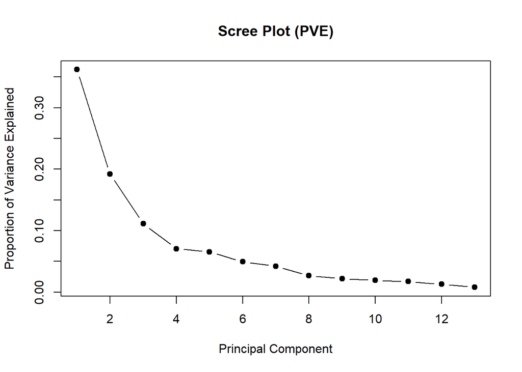

```r
plot(pve, type = "b", pch = 19,
     xlab = "Principal Component",
     ylab = "Proportion of Variance Explained",
     main = "Scree Plot (PVE)")
```

## **Biplot**

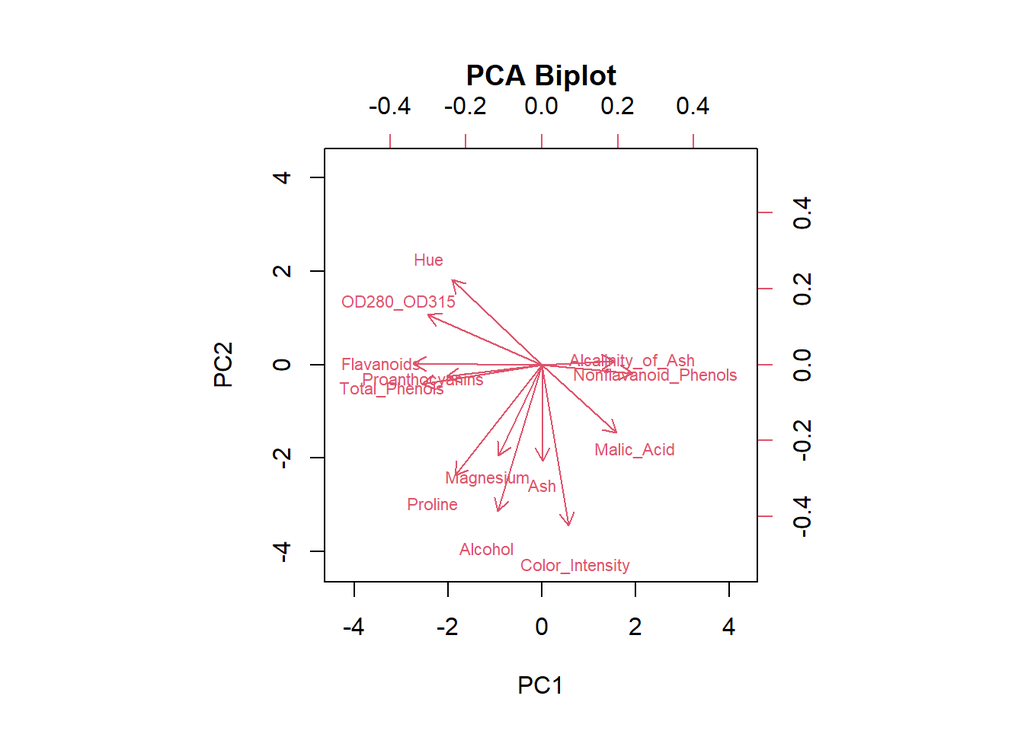

```r
biplot(pca, scale = 0, cex = 0.7,
       xlabs = rep("", nrow(X.scaled)),
       main = "PCA Biplot")
```

## **PCA Scatter Plot**

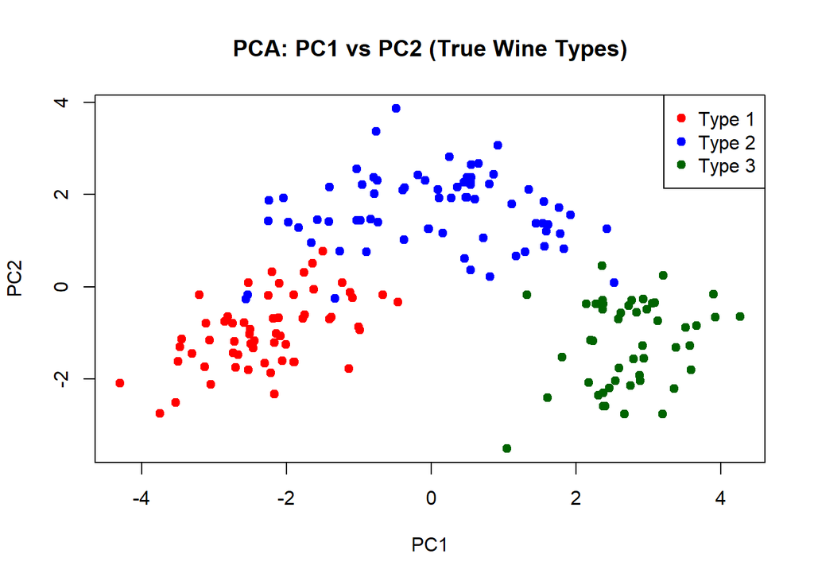

```r
# Extract PC1 and PC2 scores
scores <- pca$x[, 1:2]

# Colors for wine types
colors <- c("red", "blue", "darkgreen")

plot(scores[,1], scores[,2],
     col = colors[y], pch = 19,
     xlab = "PC1", ylab = "PC2",
     main = "PCA: PC1 vs PC2 (True Wine Types)")
legend("topright", legend = c("Type 1", "Type 2", "Type 3"),
       pch = 19, col = colors)
```

#### The scatter plot of PC1 vs PC2 shows that the wines form three partially separated clusters in PCA space, suggesting that the chemical composition contains enough structure for unsupervised clustering methods to identify meaningful groups.

## **Elbow Plot**

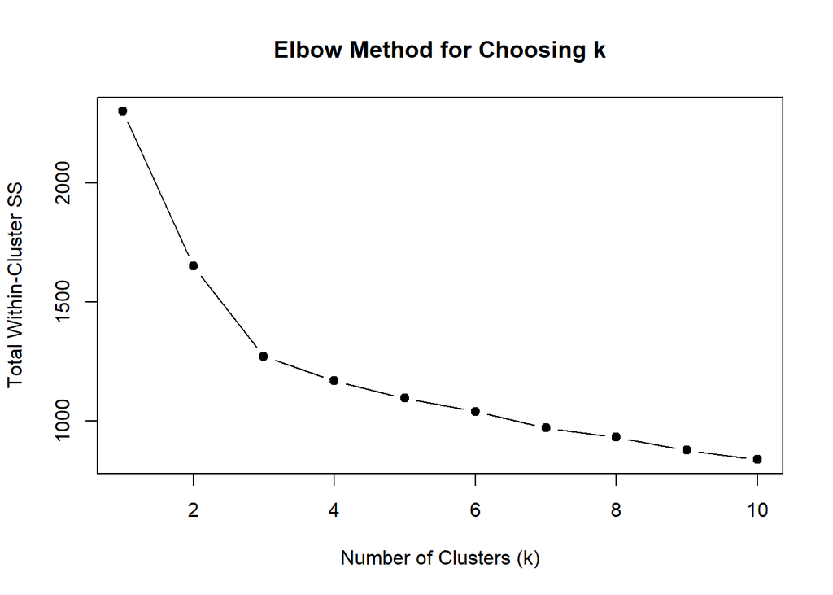

```r
# Elbow Method
wss <- numeric(10)
for (k in 1:10) {
  km.temp <- kmeans(X.scaled, centers = k, nstart = 20)
  wss[k] <- km.temp$tot.withinss
}

plot(1:10, wss, type = "b", pch = 19,
     xlab = "Number of Clusters (k)",
     ylab = "Total Within-Cluster SS",
     main = "Elbow Method for Choosing k")
```

## **K-means Clustering

```r
set.seed(123)
km <- kmeans(X.scaled, centers = 3, nstart = 50)

# Cluster sizes and table vs true labels
km$size
```

```
## [1] 51 62 65
```

```r
table(km$cluster, y)
```

```
##    y
##      1  2  3
##   1  0  3 48
##   2 59  3  0
##   3  0 65  0
```

## **K-means Cluster Plot (in PCA space)**

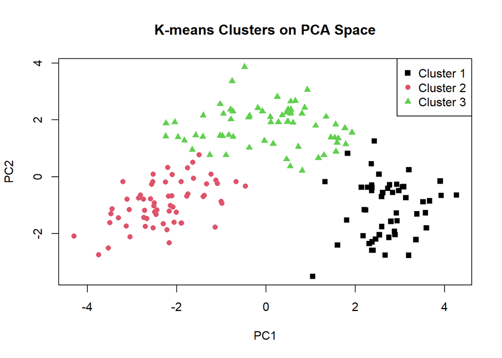

```r
plot(scores[,1], scores[,2],
     col = km$cluster,
     pch = km$cluster + 14,
     xlab = "PC1", ylab = "PC2",
     main = "K-means Clusters on PCA Space")

legend("topright", legend = paste("Cluster", 1:3),
       pch = 15:17, col = 1:3)
```

## **Hierarchical Clustering (complete linkage)**

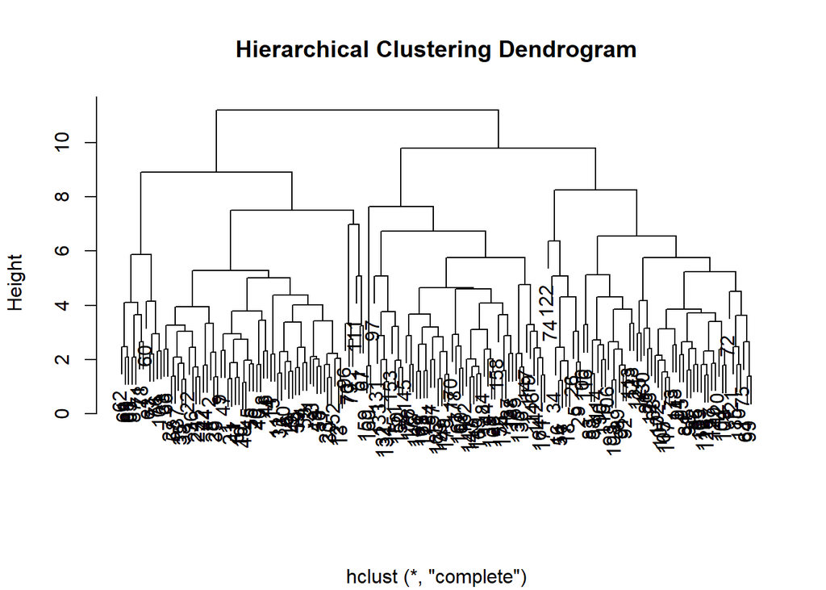

```r
# Distance matrix
d <- dist(X.scaled)

# Hierarchical clustering
hc <- hclust(d, method = "complete")

plot(hc, main = "Hierarchical Clustering Dendrogram",
     xlab = "", ylab = "Height")
```

## **Cut dendrogram into 3 clusters**

```r
hc.groups <- cutree(hc, k = 3)

table(hc.groups, y)
```

```
##          y
## hc.groups  1  2  3
##         1 51 18  0
##         2  8 50  0
##         3  0  3 48
```

# **Results and Model Evaluation**

## **2. Choosing k for K-means (Elbow Method)**

#### The elbow plot shows a clear “bend” at:

#### ➤ k = 3

##### This matches the true number of wine cultivars, confirming that three clusters best represent the underlying structure.

## **K-Means Clustering Results**

#### After selecting k = 3 using the elbow method, K-means clustering was applied to the standardized chemical features.

### **Cluster Sizes**

```r
km$size
```

```
## [1] 51 62 65
```

#### This indicates that K-means formed three clusters of relatively balanced sizes

### **K-means Confusion Matrix (Predicted Clusters vs True Wine Types)**

```r
km_table <- table(km$cluster, y)
km_table
```

```
##    y
##      1  2  3
##   1  0  3 48
##   2 59  3  0
##   3  0 65  0
```

#### K-means successfully discovers three distinct groups, and although the numerical cluster labels do not match the wine type numbers directly (which is expected), the overall grouping pattern aligns well with the true underlying classes:

#### - Cluster 1 corresponds mainly to Type 3

#### - Cluster 2 corresponds mainly to Type 1

#### - Cluster 3 corresponds mainly to Type 2

#### The clustering captures the general structure, with only a small number of cross-cluster assignments.

## **Hierarchical Clustering Results**

#### Hierarchical clustering using complete linkage was performed on the standardized distance matrix. Cutting the dendrogram at k = 3 produces the following grouping:

```r
hc_table <- table(hc.groups, y)
hc_table
```

```
##          y
## hc.groups  1  2  3
##         1 51 18  0
##         2  8 50  0
##         3  0  3 48
```

#### This consistency across clusters suggests that the underlying chemical variation naturally supports a three-group structure.

## **Comparing Clustering Methods**

#### This is consistent with PCA visualizations, which show clear separation between wine types, particularly in the first two principal components.

# **Discussion of Insights**

## **Clustering Performance and Feature Influence**

#### The necessity of data standardization was evident: the large range of values for variables like Proline (ranging from 300$ to 1700) would have improperly dominated the distance metrics used in clustering had the data not been scaled. The success of the clustering methods confirms that, once standardized, all chemical features contribute equitably to defining the groups.

# **Conclusion and Limitations**

## **Conclusion**

# **Limitations**

#### **Dependency on Data Scale**: The success of the clustering was highly dependent on the initial standardization of the data. Without scaling, features with large ranges (like Proline) would have heavily skewed the results, a limitation inherent to distance-based clustering.

#### **Model Selection**: The determination of the optimal number of clusters, k=3, relied on the Elbow Method, which can sometimes be ambiguous. While the result aligned with the known answer, in a truly unsupervised scenario, alternative metrics would be necessary for a more robust k selection.

#### **Generalizability**: The analysis is restricted to the UCI Wine dataset, which consists of wines from a single region in Italy. Applying these models to wines from different regions or with different chemical measurement techniques may require recalibration.

# **Appendices**

#### **Data Source**:

#### The data used for this project is the UCI Wine dataset.

#### Original Source: UCI Machine Learning Repository

#### Data Link: https://archive.ics.uci.edu/ml/machine-learning-databases/wine/wine.data